# RPC-PI Experiment - Total Pipeline Runtime Analysis

2026-07-04

# 1 Objective

This R Markdown analyzes the **total runtime cost of the experimental pipeline**.

It combines logs from:

```
training
inference
metrics
pairwise_metrics
statistical_analysis
error_analysis
```

The main questions are:

```
How long did the complete pipeline take?
Which stage dominates the runtime?
How much time was spent in training, inference, pairwise/judge metrics, and analysis?
How many runs, rows, events, and errors are associated with each stage?
Where are the main pipeline bottlenecks?
```

This report is complementary to:

```
14_training_time_analysis.Rmd
15_inference_time_analysis.Rmd
```

The focus here is not only model cost, but **end-to-end experiment cost**.

# 2 Expected folder structure

This Rmd expects the logs extracted into one of these locations:

```
data/logs/
logs/
```

If `logs.zip` exists in the project root or inside `data/`, this Rmd tries to extract it automatically to `data/`.

# 3 Paths

```r
OUT_TABLE_DIR <- here::here("tables", "pipeline_runtime_analysis")
OUT_FIG_DIR <- here::here("figures", "pipeline_runtime_analysis")

fs::dir_create(OUT_TABLE_DIR)
fs::dir_create(OUT_FIG_DIR)

# Try to extract logs.zip automatically if needed.
if (!dir.exists(here::here("data", "logs")) && file.exists(here::here("logs.zip"))) {
  dir.create(here::here("data"), showWarnings = FALSE)
  unzip(here::here("logs.zip"), exdir = here::here("data"))
}

if (!dir.exists(here::here("data", "logs")) && file.exists(here::here("data", "logs.zip"))) {
  dir.create(here::here("data"), showWarnings = FALSE)
  unzip(here::here("data", "logs.zip"), exdir = here::here("data"))
}

candidate_logs_dirs <- c(
  here::here("data", "logs"),
  here::here("logs")
)

LOGS_DIR <- candidate_logs_dirs[dir.exists(candidate_logs_dirs)][1]

if (is.na(LOGS_DIR)) {
  stop(
    "Could not find logs directory. Expected one of:\n",
    paste(candidate_logs_dirs, collapse = "\n"),
    "\nOr place logs.zip in the project root or data/."
  )
}
```

# 4 Helper functions

```r
`%||%` <- function(x, y) {
  if (is.null(x) || length(x) == 0) y else x
}

scenario_order <- c(
  "c0_base",
  "c1_struq_format_only",
  "c2_struq_sft",
  "c3_secalign_dpo",
  "c4_ih_sft"
)

scenario_labels <- tibble(
  scenario_id = scenario_order,
  scenario_short = c("C0", "C1", "C2", "C3", "C4"),
  scenario_label = c(
    "C0 - Base model",
    "C1 - StruQ format-only",
    "C2 - StruQ-like SFT",
    "C3 - SecAlign-like DPO",
    "C4 - Instruction-Hierarchy-like SFT"
  )
)

scenario_palette <- c(
  C0 = "#7F7F7F",
  C1 = "#D55E00",
  C2 = "#0072B2",
  C3 = "#CC79A7",
  C4 = "#009E73"
)

stage_order <- c(
  "training",
  "inference",
  "metrics",
  "pairwise_metrics",
  "statistical_analysis",
  "error_analysis"
)

stage_labels <- c(
  training = "Training",
  inference = "Inference",
  metrics = "Metrics",
  pairwise_metrics = "Pairwise metrics",
  statistical_analysis = "Statistical analysis",
  error_analysis = "Error analysis"
)

stage_palette <- c(
  training = "#0072B2",
  inference = "#009E73",
  metrics = "#E69F00",
  pairwise_metrics = "#CC79A7",
  statistical_analysis = "#56B4E9",
  error_analysis = "#D55E00"
)

sort_stages <- function(df) {
  df |>
    mutate(
      stage = factor(as.character(stage), levels = stage_order),
      stage_label = factor(
        ifelse(is.na(stage_labels[as.character(stage)]), as.character(stage), stage_labels[as.character(stage)]),
        levels = stage_labels[stage_order]
      )
    ) |>
    arrange(stage)
}

sort_scenarios <- function(df) {
  df |>
    mutate(
      scenario_id = factor(as.character(scenario_id), levels = scenario_order),
      scenario_short = factor(as.character(scenario_short), levels = c("C0", "C1", "C2", "C3", "C4"))
    ) |>
    arrange(scenario_id)
}

add_scenario_info <- function(df) {
  if (!("scenario_id" %in% names(df))) {
    df$scenario_id <- NA_character_
  }

  out <- df |>
    mutate(scenario_id = as.character(scenario_id)) |>
    left_join(scenario_labels, by = "scenario_id", suffix = c("", "_lookup"))

  if (!("scenario_label" %in% names(out))) {
    out$scenario_label <- out$scenario_id
  }

  if ("scenario_label_lookup" %in% names(out)) {
    out <- out |>
      mutate(
        scenario_label = coalesce(
          as.character(scenario_label),
          as.character(scenario_label_lookup)
        )
      )
  }

  if (!("scenario_short" %in% names(out))) {
    out$scenario_short <- NA_character_
  }

  if ("scenario_short_lookup" %in% names(out)) {
    out <- out |>
      mutate(
        scenario_short = coalesce(
          as.character(scenario_short),
          as.character(scenario_short_lookup)
        )
      )
  }

  out |>
    mutate(
      scenario_short = ifelse(
        is.na(scenario_short),
        recode(
          as.character(scenario_id),
          c0_base = "C0",
          c1_struq_format_only = "C1",
          c2_struq_sft = "C2",
          c3_secalign_dpo = "C3",
          c4_ih_sft = "C4",
          .default = as.character(scenario_id)
        ),
        scenario_short
      )
    ) |>
    select(-any_of(c("scenario_label_lookup", "scenario_short_lookup"))) |>
    sort_scenarios()
}

parse_time_utc <- function(x) {
  lubridate::ymd_hms(x, tz = "UTC", quiet = TRUE)
}

safe_mean <- function(x) {
  if (sum(!is.na(x)) == 0) return(NA_real_)
  mean(x, na.rm = TRUE)
}

safe_sd <- function(x) {
  if (sum(!is.na(x)) <= 1) return(NA_real_)
  sd(x, na.rm = TRUE)
}

fmt_duration <- function(seconds) {
  ifelse(
    is.na(seconds),
    NA_character_,
    paste0(
      floor(seconds / 3600), "h ",
      floor((seconds %% 3600) / 60), "m ",
      round(seconds %% 60), "s"
    )
  )
}

fmt_number <- function(x, accuracy = 0.01) {
  scales::number(x, accuracy = accuracy, big.mark = ",")
}

fmt_pct <- function(x, accuracy = 0.1) {
  scales::percent(x, accuracy = accuracy)
}

base_theme <- function(base_size = 12) {
  theme_minimal(base_size = base_size) +
    theme(
      legend.position = "bottom",
      plot.title.position = "plot",
      plot.title = element_text(face = "bold"),
      plot.subtitle = element_text(color = "grey30"),
      panel.grid.minor = element_blank(),
      axis.title = element_text(face = "bold")
    )
}

sanitize_for_csv <- function(df) {
  df <- as_tibble(df)
  n_rows <- nrow(df)

  value_to_text <- function(value) {
    if (is.null(value) || length(value) == 0) {
      return(NA_character_)
    }

    tryCatch(
      as.character(jsonlite::toJSON(value, auto_unbox = TRUE, null = "null")),
      error = function(e) paste(capture.output(str(value)), collapse = " ")
    )
  }

  for (nm in names(df)) {
    col <- df[[nm]]

    if (is.data.frame(col)) {
      if (nrow(col) == n_rows) {
        df[[nm]] <- purrr::map_chr(
          seq_len(n_rows),
          function(i) value_to_text(as.list(col[i, , drop = FALSE]))
        )
      } else {
        df[[nm]] <- rep(value_to_text(col), n_rows)
      }
    } else if (is.matrix(col) || is.array(col)) {
      mat <- as.matrix(col)

      if (nrow(mat) == n_rows) {
        df[[nm]] <- apply(
          mat,
          1,
          function(row) paste(as.character(row), collapse = " | ")
        )
      } else {
        df[[nm]] <- rep(value_to_text(mat), n_rows)
      }
    } else if (is.list(col)) {
      if (length(col) == n_rows) {
        df[[nm]] <- purrr::map_chr(col, value_to_text)
      } else if (length(col) == 1) {
        df[[nm]] <- rep(value_to_text(col[[1]]), n_rows)
      } else {
        df[[nm]] <- rep(value_to_text(col), n_rows)
      }
    }
  }

  df
}

write_pipeline_csv <- function(df, filename) {
  safe_df <- sanitize_for_csv(df)
  readr::write_csv(safe_df, file.path(OUT_TABLE_DIR, filename))
  invisible(df)
}

save_pipeline_figure <- function(plot, filename, width = 10, height = 6) {
  ggsave(
    file.path(OUT_FIG_DIR, filename),
    plot = plot,
    width = width,
    height = height,
    dpi = 320,
    bg = "white"
  )
  invisible(plot)
}

replace_null_columns <- function(x) {
  if (!is.list(x)) {
    return(x)
  }

  n <- 1
  non_null_lengths <- purrr::map_int(
    x,
    function(value) {
      if (is.null(value)) {
        0L
      } else if (is.data.frame(value)) {
        nrow(value)
      } else {
        length(value)
      }
    }
  )

  if (any(non_null_lengths > 0)) {
    n <- max(non_null_lengths)
  }

  purrr::map(
    x,
    function(value) {
      if (is.null(value)) {
        rep(NA_character_, n)
      } else {
        value
      }
    }
  )
}

as_tibble_json_safe <- function(x) {
  if (is.null(x)) {
    return(tibble())
  }

  if (is.data.frame(x)) {
    x <- replace_null_columns(x)
    return(tibble::as_tibble(x))
  }

  if (is.list(x)) {
    x <- replace_null_columns(x)
    return(tibble::as_tibble(x))
  }

  tibble(value = x)
}

read_jsonl_robust <- function(path, stage_name, bad_lines_filename = "00_bad_jsonl_lines.csv") {
  if (!file.exists(path)) {
    return(tibble())
  }

  lines <- readLines(path, warn = FALSE, encoding = "UTF-8")

  if (length(lines) == 0) {
    return(tibble())
  }

  parsed <- vector("list", length(lines))
  bad_lines <- list()

  for (i in seq_along(lines)) {
    line <- lines[[i]]

    if (is.na(line) || trimws(line) == "") {
      next
    }

    obj <- tryCatch(
      jsonlite::fromJSON(line, flatten = TRUE),
      error = function(e) {
        bad_lines[[length(bad_lines) + 1]] <<- tibble(
          stage = stage_name,
          line_number = i,
          error = conditionMessage(e),
          line_prefix = substr(line, 1, 250)
        )
        NULL
      }
    )

    if (!is.null(obj)) {
      parsed[[i]] <- as_tibble_json_safe(obj)
    }
  }

  parsed <- parsed[!vapply(parsed, is.null, logical(1))]
  bad_lines_df <- dplyr::bind_rows(bad_lines)

  if (nrow(bad_lines_df) > 0) {
    readr::write_csv(
      bad_lines_df,
      file.path(OUT_TABLE_DIR, bad_lines_filename)
    )
  }

  if (length(parsed) == 0) {
    return(tibble())
  }

  dplyr::bind_rows(parsed) |>
    mutate(stage = stage_name, .before = 1)
}

get_scalar <- function(obj, field, default = NA) {
  value <- obj[[field]]

  if (is.null(value) || length(value) == 0) {
    return(default)
  }

  if (is.data.frame(value)) {
    if (nrow(value) == 0 || ncol(value) == 0) return(default)
    return(value[[1]][[1]])
  }

  if (is.list(value) && length(value) == 1 && !is.null(value[[1]])) {
    return(value[[1]])
  }

  value[[1]]
}

get_nested_scalar <- function(obj, parent, child, default = NA) {
  flat_name <- paste0(parent, ".", child)

  flat_value <- obj[[flat_name]]

  if (!is.null(flat_value) && length(flat_value) > 0) {
    return(flat_value[[1]])
  }

  parent_value <- obj[[parent]]

  if (!is.null(parent_value)) {
    if (is.data.frame(parent_value) && child %in% names(parent_value)) {
      return(parent_value[[child]][[1]])
    }

    if (is.list(parent_value) && !is.null(parent_value[[child]])) {
      return(parent_value[[child]][[1]])
    }
  }

  default
}

read_json_safe <- function(path) {
  tryCatch(
    jsonlite::fromJSON(path, flatten = TRUE),
    error = function(e) NULL
  )
}
```

# 5 Discover log files

```r
stage_paths <- tibble(
  stage = stage_order,
  stage_label = stage_labels[stage_order],
  stage_dir = file.path(LOGS_DIR, stage_order)
) |>
  mutate(
    dir_exists = dir.exists(stage_dir),
    event_path = case_when(
      stage == "training" ~ file.path(stage_dir, "04_run_training_events.jsonl"),
      stage == "inference" ~ file.path(stage_dir, "05_run_inference_events.jsonl"),
      stage == "metrics" ~ file.path(stage_dir, "06_compute_metrics_events.jsonl"),
      stage == "pairwise_metrics" ~ file.path(stage_dir, "07_pairwise_and_injected_metrics_events.jsonl"),
      stage == "statistical_analysis" ~ file.path(stage_dir, "08_statistical_analysis_events.jsonl"),
      stage == "error_analysis" ~ file.path(stage_dir, "09_error_analysis_events.jsonl"),
      TRUE ~ NA_character_
    ),
    summary_path = case_when(
      stage == "training" ~ file.path(stage_dir, "04_run_training_summary.json"),
      stage == "inference" ~ file.path(stage_dir, "05_run_inference_summary.json"),
      stage == "metrics" ~ file.path(stage_dir, "06_compute_metrics_summary_full.json"),
      stage == "pairwise_metrics" ~ file.path(stage_dir, "07_pairwise_and_injected_metrics_summary.json"),
      stage == "statistical_analysis" ~ file.path(stage_dir, "08_statistical_analysis_summary_full.json"),
      stage == "error_analysis" ~ file.path(stage_dir, "09_error_analysis_summary.json"),
      TRUE ~ NA_character_
    ),
    event_exists = file.exists(event_path),
    summary_exists = file.exists(summary_path)
  ) |>
  sort_stages()

write_pipeline_csv(stage_paths, "01_stage_paths.csv")

stage_paths |>
  knitr::kable(
    caption = "Table 1 - Discovered pipeline log files."
  )
```

Table 1 - Discovered pipeline log files.

| stage | stage_label | stage_dir | dir_exists | event_path | summary_path | event_exists | summary_exists |
| --- | --- | --- | --- | --- | --- | --- | --- |
| training | Training | D:/LETICIA/UFCG/RPC/RPC-PI-EXPERIMENT/pi-defense-analysis/data/logs/training | TRUE | D:/LETICIA/UFCG/RPC/RPC-PI-EXPERIMENT/pi-defense-analysis/data/logs/training/04_run_training_events.jsonl | D:/LETICIA/UFCG/RPC/RPC-PI-EXPERIMENT/pi-defense-analysis/data/logs/training/04_run_training_summary.json | TRUE | TRUE |
| inference | Inference | D:/LETICIA/UFCG/RPC/RPC-PI-EXPERIMENT/pi-defense-analysis/data/logs/inference | TRUE | D:/LETICIA/UFCG/RPC/RPC-PI-EXPERIMENT/pi-defense-analysis/data/logs/inference/05_run_inference_events.jsonl | D:/LETICIA/UFCG/RPC/RPC-PI-EXPERIMENT/pi-defense-analysis/data/logs/inference/05_run_inference_summary.json | TRUE | TRUE |
| metrics | Metrics | D:/LETICIA/UFCG/RPC/RPC-PI-EXPERIMENT/pi-defense-analysis/data/logs/metrics | TRUE | D:/LETICIA/UFCG/RPC/RPC-PI-EXPERIMENT/pi-defense-analysis/data/logs/metrics/06_compute_metrics_events.jsonl | D:/LETICIA/UFCG/RPC/RPC-PI-EXPERIMENT/pi-defense-analysis/data/logs/metrics/06_compute_metrics_summary_full.json | TRUE | TRUE |
| pairwise_metrics | Pairwise metrics | D:/LETICIA/UFCG/RPC/RPC-PI-EXPERIMENT/pi-defense-analysis/data/logs/pairwise_metrics | TRUE | D:/LETICIA/UFCG/RPC/RPC-PI-EXPERIMENT/pi-defense-analysis/data/logs/pairwise_metrics/07_pairwise_and_injected_metrics_events.jsonl | D:/LETICIA/UFCG/RPC/RPC-PI-EXPERIMENT/pi-defense-analysis/data/logs/pairwise_metrics/07_pairwise_and_injected_metrics_summary.json | TRUE | TRUE |
| statistical_analysis | Statistical analysis | D:/LETICIA/UFCG/RPC/RPC-PI-EXPERIMENT/pi-defense-analysis/data/logs/statistical_analysis | TRUE | D:/LETICIA/UFCG/RPC/RPC-PI-EXPERIMENT/pi-defense-analysis/data/logs/statistical_analysis/08_statistical_analysis_events.jsonl | D:/LETICIA/UFCG/RPC/RPC-PI-EXPERIMENT/pi-defense-analysis/data/logs/statistical_analysis/08_statistical_analysis_summary_full.json | TRUE | TRUE |
| error_analysis | Error analysis | D:/LETICIA/UFCG/RPC/RPC-PI-EXPERIMENT/pi-defense-analysis/data/logs/error_analysis | TRUE | D:/LETICIA/UFCG/RPC/RPC-PI-EXPERIMENT/pi-defense-analysis/data/logs/error_analysis/09_error_analysis_events.jsonl | D:/LETICIA/UFCG/RPC/RPC-PI-EXPERIMENT/pi-defense-analysis/data/logs/error_analysis/09_error_analysis_summary.json | TRUE | TRUE |

# 6 Load all stage events

```r
all_events <- purrr::map2_dfr(
  stage_paths$event_path,
  stage_paths$stage,
  function(path, stage_name) {
    read_jsonl_robust(
      path = path,
      stage_name = stage_name,
      bad_lines_filename = "00_bad_pipeline_event_lines.csv"
    )
  }
)

if (nrow(all_events) == 0) {
  stop("No pipeline events could be loaded.")
}

events_raw_names <- names(all_events)

if (!("scenario_id" %in% events_raw_names) && "scenario" %in% events_raw_names) {
  all_events <- all_events |>
    rename(scenario_id = scenario)
} else if ("scenario" %in% events_raw_names) {
  all_events <- all_events |>
    mutate(
      scenario_id = coalesce(
        as.character(scenario_id),
        as.character(scenario)
      )
    )
}

if (!("seed" %in% names(all_events))) {
  all_events$seed <- NA_integer_
}

if (!("event_type" %in% names(all_events))) {
  all_events$event_type <- NA_character_
}

if (!("timestamp_utc" %in% names(all_events))) {
  stop("Events do not contain timestamp_utc.")
}

if (!("run_mode" %in% names(all_events))) {
  all_events$run_mode <- NA_character_
}

if (!("rows" %in% names(all_events))) {
  all_events$rows <- NA_real_
}

if (!("elapsed_seconds" %in% names(all_events))) {
  all_events$elapsed_seconds <- NA_real_
}

all_events <- all_events |>
  mutate(
    stage = as.character(stage),
    event_type = as.character(event_type),
    timestamp = parse_time_utc(timestamp_utc),
    scenario_id = as.character(scenario_id),
    seed = suppressWarnings(as.integer(seed)),
    run_mode = as.character(run_mode),
    rows = suppressWarnings(as.numeric(rows)),
    elapsed_seconds = suppressWarnings(as.numeric(elapsed_seconds))
  ) |>
  add_scenario_info() |>
  sort_stages()

write_pipeline_csv(all_events, "02_all_pipeline_events.csv")

all_events |>
  count(stage_label, event_type, name = "n_events") |>
  arrange(stage_label, desc(n_events)) |>
  knitr::kable(
    caption = "Table 2 - Event counts by stage."
  )
```

Table 2 - Event counts by stage.

| stage_label | event_type | n_events |
| --- | --- | --- |
| Training | run_completed | 108 |
| Training | run_started | 20 |
| Training | run_failed | 1 |
| Inference | split_completed | 66 |
| Inference | split_started | 66 |
| Inference | run_started | 23 |
| Inference | run_completed | 22 |
| Inference | run_failed | 1 |
| Metrics | inference_files_discovered | 3 |
| Metrics | inference_results_loaded | 3 |
| Metrics | metrics_files_generated | 3 |
| Metrics | metrics_manifest_created | 3 |
| Metrics | metrics_notebook_started | 3 |
| Pairwise metrics | injected_only_split_started | 33 |
| Pairwise metrics | injected_only_split_completed | 30 |
| Pairwise metrics | injected_only_run_started | 22 |
| Pairwise metrics | injected_only_run_completed | 16 |
| Pairwise metrics | win_rate_group_completed | 10 |
| Pairwise metrics | win_rate_group_started | 10 |
| Pairwise metrics | injected_only_run_skipped_existing | 7 |
| Pairwise metrics | injected_only_run_failed | 3 |
| Pairwise metrics | judge_model_loading_completed | 1 |
| Pairwise metrics | judge_model_loading_started | 1 |
| Pairwise metrics | win_rate_judging_completed | 1 |
| Pairwise metrics | win_rate_judging_started | 1 |
| Statistical analysis | metrics_06_loaded | 1 |
| Statistical analysis | metrics_07_loaded | 1 |
| Statistical analysis | statistical_analysis_completed | 1 |
| Statistical analysis | statistical_analysis_files_generated | 1 |
| Statistical analysis | statistical_analysis_started | 1 |
| Error analysis | manifests_loaded | 6 |
| Error analysis | qualitative_samples_created | 4 |
| Error analysis | coverage_table_created | 1 |
| Error analysis | discussion_tables_created | 1 |
| Error analysis | failure_taxonomy_created | 1 |
| Error analysis | inference_outputs_loaded | 1 |
| Error analysis | invalid_outputs_created | 1 |
| Error analysis | manifest_created | 1 |
| Error analysis | notebook_started | 1 |
| Error analysis | paired_vs_c0_created | 1 |
| Error analysis | qualitative_summary_created | 1 |
| Error analysis | seen_unseen_analysis_created | 1 |
| Error analysis | shared_failures_created | 1 |
| Error analysis | task_and_attack_error_tables_created | 1 |

# 7 Stage timelines from event logs

```r
stage_event_summary <- all_events |>
  group_by(stage, stage_label) |>
  summarise(
    n_events = n(),
    first_event_utc = min(timestamp, na.rm = TRUE),
    last_event_utc = max(timestamp, na.rm = TRUE),
    observed_stage_seconds = as.numeric(difftime(last_event_utc, first_event_utc, units = "secs")),
    observed_stage_minutes = observed_stage_seconds / 60,
    observed_stage_hours = observed_stage_seconds / 3600,
    event_elapsed_seconds_sum = sum(elapsed_seconds, na.rm = TRUE),
    event_rows_sum = sum(rows, na.rm = TRUE),
    n_event_rows_with_elapsed = sum(!is.na(elapsed_seconds)),
    n_event_rows_with_rows = sum(!is.na(rows)),
    .groups = "drop"
  ) |>
  sort_stages()

pipeline_start <- min(stage_event_summary$first_event_utc, na.rm = TRUE)
pipeline_end <- max(stage_event_summary$last_event_utc, na.rm = TRUE)
pipeline_wall_clock_seconds <- as.numeric(difftime(pipeline_end, pipeline_start, units = "secs"))

stage_event_summary <- stage_event_summary |>
  mutate(
    share_of_wall_clock = observed_stage_seconds / pipeline_wall_clock_seconds,
    observed_duration_label = fmt_duration(observed_stage_seconds)
  )

write_pipeline_csv(stage_event_summary, "03_stage_event_timeline_summary.csv")

stage_event_summary |>
  select(
    stage_label,
    n_events,
    first_event_utc,
    last_event_utc,
    observed_stage_minutes,
    observed_stage_hours,
    share_of_wall_clock,
    event_elapsed_seconds_sum,
    event_rows_sum,
    observed_duration_label
  ) |>
  mutate(
    observed_stage_minutes = fmt_number(observed_stage_minutes),
    observed_stage_hours = fmt_number(observed_stage_hours),
    share_of_wall_clock = fmt_pct(share_of_wall_clock),
    event_elapsed_seconds_sum = fmt_number(event_elapsed_seconds_sum),
    event_rows_sum = fmt_number(event_rows_sum, accuracy = 1)
  ) |>
  knitr::kable(
    caption = "Table 3 - Stage timeline summary based on event timestamps."
  )
```

Table 3 - Stage timeline summary based on event timestamps.

| stage_label | n_events | first_event_utc | last_event_utc | observed_stage_minutes | observed_stage_hours | share_of_wall_clock | event_elapsed_seconds_sum | event_rows_sum | observed_duration_label |
| --- | --- | --- | --- | --- | --- | --- | --- | --- | --- |
| Training | 129 | 2026-06-29 11:37:58 | 2026-06-29 19:14:00 | 456.03 | 7.60 | 27.9% | 128,175.75 | 0 | 7h 36m 2s |
| Inference | 178 | 2026-06-29 20:54:16 | 2026-06-29 23:30:17 | 156.01 | 2.60 | 9.6% | 18,044.75 | 372,768 | 2h 36m 1s |
| Metrics | 15 | 2026-06-30 00:58:56 | 2026-06-30 02:34:08 | 95.20 | 1.59 | 5.8% | 0.00 | 0 | 1h 35m 12s |
| Pairwise metrics | 135 | 2026-06-30 03:07:24 | 2026-06-30 05:31:47 | 144.37 | 2.41 | 8.8% | 11,863.45 | 481,380 | 2h 24m 22s |
| Statistical analysis | 5 | 2026-06-30 14:40:40 | 2026-06-30 14:40:41 | 0.02 | 0.00 | 0.0% | 0.00 | 0 | 0h 0m 1s |
| Error analysis | 22 | 2026-06-30 14:51:10 | 2026-06-30 14:51:27 | 0.28 | 0.00 | 0.0% | 0.00 | 200,864 | 0h 0m 17s |

# 8 Load summary JSON files

```r
summary_records <- purrr::pmap_dfr(
  stage_paths |>
    select(stage, stage_label, summary_path, summary_exists),
  function(stage, stage_label, summary_path, summary_exists) {
    if (!isTRUE(summary_exists)) {
      return(tibble(
        stage = stage,
        stage_label = stage_label,
        summary_exists = FALSE
      ))
    }

    obj <- read_json_safe(summary_path)

    if (is.null(obj)) {
      return(tibble(
        stage = stage,
        stage_label = stage_label,
        summary_exists = TRUE,
        summary_parse_ok = FALSE
      ))
    }

    counts <- obj$counts %||% list()
    outputs <- obj$outputs %||% list()

    tibble(
      stage = stage,
      stage_label = stage_label,
      summary_exists = TRUE,
      summary_parse_ok = TRUE,
      notebook = as.character(obj$notebook %||% NA_character_),
      created_at_utc = as.character(obj$created_at_utc %||% NA_character_),
      run_mode = as.character(obj$run_mode %||% NA_character_),
      base_model_id = as.character(obj$base_model_id %||% obj$base_model %||% NA_character_),
      judge_model_id = as.character(obj$judge_model_id %||% NA_character_),
      num_inference_rows = as.numeric(obj$num_inference_rows %||% NA_real_),
      total_inference_rows = as.numeric(obj$total_inference_rows %||% NA_real_),
      num_scenarios = as.numeric(obj$num_scenarios %||% NA_real_),
      num_scenario_seed_runs = as.numeric(obj$num_scenario_seed_runs %||% NA_real_),
      training_results_count = length(obj$training_results %||% list()),
      inference_results_count = length(obj$inference_results %||% list()),
      result_files_count = length(obj$result_files %||% list()),
      input_files_count = length(obj$input_files %||% list()),
      generated_files_count = length(obj$generated_files %||% list()),
      metrics_computed_count = length(obj$metrics_computed %||% list()),
      metrics_available_count = length(obj$metrics_available %||% list()),
      outputs_count = length(outputs),
      counts_injected_only_rows = as.numeric(counts$injected_only_rows %||% NA_real_),
      counts_mr_paired_rows = as.numeric(counts$mr_paired_rows %||% NA_real_),
      counts_win_rate_pairs = as.numeric(counts$win_rate_pairs %||% NA_real_),
      counts_win_rate_judgments = as.numeric(counts$win_rate_judgments %||% NA_real_),
      counts_unified_run_rows = as.numeric(counts$unified_run_rows %||% NA_real_),
      counts_scenario_metric_summary_rows = as.numeric(counts$scenario_metric_summary_rows %||% NA_real_),
      coverage_rows = as.numeric(obj$coverage_rows %||% NA_real_),
      failure_taxonomy_rows = as.numeric(obj$failure_taxonomy_rows %||% NA_real_),
      paired_vs_c0_rows = as.numeric(obj$paired_vs_c0_rows %||% NA_real_),
      invalid_output_rows = as.numeric(obj$invalid_output_rows %||% NA_real_),
      summary_path = summary_path
    )
  }
) |>
  sort_stages()

write_pipeline_csv(summary_records, "04_stage_summary_json_records.csv")

summary_records |>
  select(
    stage_label,
    notebook,
    created_at_utc,
    run_mode,
    base_model_id,
    judge_model_id,
    training_results_count,
    inference_results_count,
    result_files_count,
    input_files_count,
    generated_files_count,
    metrics_computed_count,
    outputs_count
  ) |>
  knitr::kable(
    caption = "Table 4 - Summary JSON overview by stage."
  )
```

Table 4 - Summary JSON overview by stage.

| stage_label | notebook | created_at_utc | run_mode | base_model_id | judge_model_id | training_results_count | inference_results_count | result_files_count | input_files_count | generated_files_count | metrics_computed_count | outputs_count |
| --- | --- | --- | --- | --- | --- | --- | --- | --- | --- | --- | --- | --- |
| Training | 04_run_training | 2026-06-29T19:14:00.238277+00:00 | - | meta-llama/Llama-3.1-8B-Instruct | - | 17 | 0 | 0 | 0 | 0 | 0 | 0 |
| Inference | 05_run_inference | 2026-06-29T23:30:18.907722+00:00 | full | meta-llama/Llama-3.1-8B-Instruct | - | 0 | 17 | 6 | 0 | 0 | 0 | 0 |
| Metrics | 06_compute_metrics | 2026-06-30T02:34:08.535202+00:00 | full | meta-llama/Llama-3.1-8B-Instruct | - | 0 | 1 | 0 | 6 | 4 | 0 | 0 |
| Pairwise metrics | 07_pairwise_and_injected_metrics | 2026-06-30T05:31:47.253821+00:00 | full | meta-llama/Llama-3.1-8B-Instruct | Qwen/Qwen3-8B | 0 | 0 | 0 | 0 | 0 | 7 | 9 |
| Statistical analysis | 08_statistical_analysis | 2026-06-30T14:40:41.747197+00:00 | full | - | - | 0 | 0 | 0 | 0 | 0 | 0 | 11 |
| Error analysis | - | 2026-06-30T14:51:27.004363+00:00 | full | - | - | 0 | 0 | 0 | 0 | 0 | 0 | 11 |

# 9 Load run metadata files

```r
all_run_metadata_files <- fs::dir_ls(LOGS_DIR, recurse = TRUE, regexp = "run_metadata\\.json$")

read_generic_run_metadata <- function(path) {
  obj <- read_json_safe(path)

  if (is.null(obj)) {
    return(tibble(
      metadata_path = as.character(path),
      parse_ok = FALSE
    ))
  }

  path_chr <- as.character(path)

  stage <- case_when(
    str_detect(path_chr, "[/\\\\]training[/\\\\]") ~ "training",
    str_detect(path_chr, "[/\\\\]inference[/\\\\]") ~ "inference",
    str_detect(path_chr, "[/\\\\]pairwise_metrics[/\\\\]") ~ "pairwise_metrics",
    TRUE ~ NA_character_
  )

  substage <- case_when(
    str_detect(path_chr, "[/\\\\]pairwise_metrics[/\\\\].*[/\\\\]injected_only[/\\\\]") ~ "injected_only",
    str_detect(path_chr, "[/\\\\]pairwise_metrics[/\\\\].*[/\\\\]win_rate[/\\\\]") ~ "win_rate",
    TRUE ~ stage
  )

  scenario_id <- as.character(
    get_scalar(
      obj,
      "scenario_id",
      get_scalar(
        obj,
        "scenario",
        get_scalar(obj, "defended_scenario_id", NA_character_)
      )
    )
  )

  seed <- suppressWarnings(as.integer(
    get_scalar(
      obj,
      "seed",
      get_scalar(obj, "defended_seed", NA_integer_)
    )
  ))

  rows <- suppressWarnings(as.numeric(
    get_scalar(
      obj,
      "rows",
      get_scalar(
        obj,
        "train_rows",
        NA_real_
      )
    )
  ))

  train_rows <- suppressWarnings(as.numeric(get_scalar(obj, "train_rows", NA_real_)))
  validation_rows <- suppressWarnings(as.numeric(get_scalar(obj, "validation_rows", NA_real_)))

  splits <- obj$splits
  split_count <- if (is.null(splits)) {
    NA_integer_
  } else if (is.data.frame(splits)) {
    nrow(splits)
  } else if (is.list(splits)) {
    length(splits)
  } else {
    NA_integer_
  }

  split_rows_sum <- NA_real_
  split_elapsed_seconds_sum <- NA_real_

  if (!is.null(splits)) {
    split_tbl <- tryCatch(as_tibble_json_safe(splits), error = function(e) tibble())

    if (nrow(split_tbl) > 0) {
      if ("rows" %in% names(split_tbl)) {
        split_rows_sum <- sum(as.numeric(split_tbl$rows), na.rm = TRUE)
      }

      if ("elapsed_seconds" %in% names(split_tbl)) {
        split_elapsed_seconds_sum <- sum(as.numeric(split_tbl$elapsed_seconds), na.rm = TRUE)
      }
    }
  }

  tibble(
    stage = stage,
    substage = substage,
    scenario_id = scenario_id,
    seed = seed,
    status = as.character(get_scalar(obj, "status", NA_character_)),
    method = as.character(get_scalar(obj, "method", NA_character_)),
    run_mode = as.character(get_scalar(obj, "run_mode", NA_character_)),
    eval_split = as.character(get_scalar(obj, "eval_split", NA_character_)),
    started_at_utc = as.character(get_scalar(obj, "started_at_utc", NA_character_)),
    finished_at_utc = as.character(get_scalar(obj, "finished_at_utc", NA_character_)),
    started_at = parse_time_utc(started_at_utc),
    finished_at = parse_time_utc(finished_at_utc),
    elapsed_seconds = suppressWarnings(as.numeric(get_scalar(obj, "elapsed_seconds", NA_real_))),
    rows = rows,
    train_rows = train_rows,
    validation_rows = validation_rows,
    split_count = split_count,
    split_rows_sum = split_rows_sum,
    split_elapsed_seconds_sum = split_elapsed_seconds_sum,
    metadata_path = path_chr,
    parse_ok = TRUE
  )
}

run_metadata <- purrr::map_dfr(
  all_run_metadata_files,
  read_generic_run_metadata
) |>
  add_scenario_info() |>
  mutate(
    stage = as.character(stage),
    substage = as.character(substage),
    elapsed_minutes = elapsed_seconds / 60,
    elapsed_hours = elapsed_seconds / 3600,
    seconds_per_row = case_when(
      !is.na(split_rows_sum) & split_rows_sum > 0 ~ elapsed_seconds / split_rows_sum,
      !is.na(rows) & rows > 0 ~ elapsed_seconds / rows,
      TRUE ~ NA_real_
    ),
    rows_per_second = case_when(
      !is.na(split_rows_sum) & elapsed_seconds > 0 ~ split_rows_sum / elapsed_seconds,
      !is.na(rows) & elapsed_seconds > 0 ~ rows / elapsed_seconds,
      TRUE ~ NA_real_
    )
  ) |>
  sort_stages() |>
  sort_scenarios()

write_pipeline_csv(run_metadata, "05_all_run_metadata.csv")

run_metadata |>
  count(stage_label, substage, scenario_short, name = "n_run_metadata_files") |>
  arrange(stage_label, substage, scenario_short) |>
  knitr::kable(
    caption = "Table 5 - Run metadata files by stage, substage, and scenario."
  )
```

Table 5 - Run metadata files by stage, substage, and scenario.

| stage_label | substage | scenario_short | n_run_metadata_files |
| --- | --- | --- | --- |
| Training | training | C2 | 3 |
| Training | training | C3 | 3 |
| Training | training | C4 | 3 |
| Inference | inference | C0 | 1 |
| Inference | inference | C1 | 1 |
| Inference | inference | C2 | 3 |
| Inference | inference | C3 | 3 |
| Inference | inference | C4 | 3 |
| Pairwise metrics | injected_only | C0 | 1 |
| Pairwise metrics | injected_only | C1 | 1 |
| Pairwise metrics | injected_only | C2 | 3 |
| Pairwise metrics | injected_only | C3 | 3 |
| Pairwise metrics | injected_only | C4 | 3 |
| Pairwise metrics | win_rate | C1 | 1 |
| Pairwise metrics | win_rate | C2 | 3 |
| Pairwise metrics | win_rate | C3 | 3 |
| Pairwise metrics | win_rate | C4 | 3 |

# 10 Stage cost from run metadata

```r
stage_run_cost <- run_metadata |>
  filter(parse_ok, !is.na(stage)) |>
  group_by(stage, stage_label, substage) |>
  summarise(
    n_run_metadata_files = n(),
    n_completed_like = sum(str_detect(status, "completed"), na.rm = TRUE),
    n_error_like = sum(str_detect(status, "error|failed"), na.rm = TRUE),
    scenarios = paste(sort(unique(na.omit(as.character(scenario_short)))), collapse = ", "),
    seeds = paste(sort(unique(na.omit(seed))), collapse = ", "),
    total_run_elapsed_seconds = sum(elapsed_seconds, na.rm = TRUE),
    mean_run_elapsed_seconds = mean(elapsed_seconds, na.rm = TRUE),
    sd_run_elapsed_seconds = safe_sd(elapsed_seconds),
    total_rows_reported = sum(rows, na.rm = TRUE),
    total_split_rows = sum(split_rows_sum, na.rm = TRUE),
    total_train_rows = sum(train_rows, na.rm = TRUE),
    total_validation_rows = sum(validation_rows, na.rm = TRUE),
    total_split_elapsed_seconds = sum(split_elapsed_seconds_sum, na.rm = TRUE),
    mean_seconds_per_row = safe_mean(seconds_per_row),
    mean_rows_per_second = safe_mean(rows_per_second),
    .groups = "drop"
  ) |>
  mutate(
    total_run_elapsed_minutes = total_run_elapsed_seconds / 60,
    total_run_elapsed_hours = total_run_elapsed_seconds / 3600,
    mean_run_elapsed_minutes = mean_run_elapsed_seconds / 60,
    total_run_duration_label = fmt_duration(total_run_elapsed_seconds),
    mean_run_duration_label = fmt_duration(mean_run_elapsed_seconds)
  ) |>
  sort_stages()

write_pipeline_csv(stage_run_cost, "06_stage_cost_from_run_metadata.csv")

stage_run_cost |>
  select(
    stage_label,
    substage,
    n_run_metadata_files,
    n_completed_like,
    n_error_like,
    scenarios,
    total_run_elapsed_hours,
    mean_run_elapsed_minutes,
    total_rows_reported,
    total_split_rows,
    total_train_rows,
    total_validation_rows,
    mean_seconds_per_row,
    mean_rows_per_second,
    total_run_duration_label
  ) |>
  mutate(
    total_run_elapsed_hours = fmt_number(total_run_elapsed_hours),
    mean_run_elapsed_minutes = fmt_number(mean_run_elapsed_minutes),
    total_rows_reported = fmt_number(total_rows_reported, accuracy = 1),
    total_split_rows = fmt_number(total_split_rows, accuracy = 1),
    total_train_rows = fmt_number(total_train_rows, accuracy = 1),
    total_validation_rows = fmt_number(total_validation_rows, accuracy = 1),
    mean_seconds_per_row = fmt_number(mean_seconds_per_row, accuracy = 0.0001),
    mean_rows_per_second = fmt_number(mean_rows_per_second, accuracy = 0.001)
  ) |>
  knitr::kable(
    caption = "Table 6 - Stage cost from run metadata."
  )
```

Table 6 - Stage cost from run metadata.

| stage_label | substage | n_run_metadata_files | n_completed_like | n_error_like | scenarios | total_run_elapsed_hours | mean_run_elapsed_minutes | total_rows_reported | total_split_rows | total_train_rows | total_validation_rows | mean_seconds_per_row | mean_rows_per_second | total_run_duration_label |
| --- | --- | --- | --- | --- | --- | --- | --- | --- | --- | --- | --- | --- | --- | --- |
| Training | training | 9 | 9 | 0 | C2, C3, C4 | 2.96 | 19.70 | 31,500 | 0 | 31,500 | 5,250 | 0.3483 | 2.902 | 2h 57m 19s |
| Inference | inference | 11 | 11 | 0 | C0, C1, C2, C3, C4 | 2.50 | 13.65 | 0 | 185,724 | 0 | 0 | 0.0485 | 21.096 | 2h 30m 11s |
| Pairwise metrics | injected_only | 11 | 11 | 0 | C0, C1, C2, C3, C4 | 1.32 | 7.20 | 0 | 165,088 | 0 | 0 | 0.0288 | 35.687 | 1h 19m 14s |
| Pairwise metrics | win_rate | 10 | 10 | 0 | C1, C2, C3, C4 | 0.13 | 0.79 | 3,000 | 0 | 0 | 0 | 0.1573 | 6.385 | 0h 7m 52s |

# 11 Unified stage cost summary

```r
stage_run_cost_total <- stage_run_cost |>
  group_by(stage, stage_label) |>
  summarise(
    run_metadata_elapsed_seconds = sum(total_run_elapsed_seconds, na.rm = TRUE),
    run_metadata_files = sum(n_run_metadata_files, na.rm = TRUE),
    run_metadata_completed_like = sum(n_completed_like, na.rm = TRUE),
    run_metadata_error_like = sum(n_error_like, na.rm = TRUE),
    run_metadata_rows = sum(total_rows_reported, na.rm = TRUE),
    run_metadata_split_rows = sum(total_split_rows, na.rm = TRUE),
    run_metadata_train_rows = sum(total_train_rows, na.rm = TRUE),
    .groups = "drop"
  )

unified_stage_cost <- stage_event_summary |>
  select(
    stage,
    stage_label,
    n_events,
    first_event_utc,
    last_event_utc,
    observed_stage_seconds,
    event_elapsed_seconds_sum,
    event_rows_sum
  ) |>
  full_join(
    stage_run_cost_total,
    by = c("stage", "stage_label")
  ) |>
  full_join(
    summary_records |>
      select(
        stage,
        stage_label,
        notebook,
        created_at_utc,
        run_mode,
        training_results_count,
        inference_results_count,
        result_files_count,
        input_files_count,
        generated_files_count,
        metrics_computed_count,
        outputs_count,
        num_inference_rows,
        total_inference_rows,
        counts_injected_only_rows,
        counts_mr_paired_rows,
        counts_win_rate_pairs,
        counts_win_rate_judgments,
        paired_vs_c0_rows,
        invalid_output_rows
      ),
    by = c("stage", "stage_label")
  ) |>
  mutate(
    primary_cost_seconds = case_when(
      !is.na(run_metadata_elapsed_seconds) & run_metadata_elapsed_seconds > 0 ~ run_metadata_elapsed_seconds,
      !is.na(event_elapsed_seconds_sum) & event_elapsed_seconds_sum > 0 ~ event_elapsed_seconds_sum,
      TRUE ~ observed_stage_seconds
    ),
    primary_cost_source = case_when(
      !is.na(run_metadata_elapsed_seconds) & run_metadata_elapsed_seconds > 0 ~ "run_metadata_elapsed_sum",
      !is.na(event_elapsed_seconds_sum) & event_elapsed_seconds_sum > 0 ~ "event_elapsed_sum",
      TRUE ~ "event_timestamp_span"
    ),
    primary_cost_minutes = primary_cost_seconds / 60,
    primary_cost_hours = primary_cost_seconds / 3600,
    observed_stage_minutes = observed_stage_seconds / 60,
    observed_stage_hours = observed_stage_seconds / 3600,
    run_metadata_elapsed_hours = run_metadata_elapsed_seconds / 3600,
    primary_cost_label = fmt_duration(primary_cost_seconds)
  ) |>
  mutate(
    share_of_primary_cost = primary_cost_seconds / sum(primary_cost_seconds, na.rm = TRUE),
    share_of_observed_stage_span = observed_stage_seconds / sum(observed_stage_seconds, na.rm = TRUE)
  ) |>
  sort_stages()

pipeline_summary <- tibble(
  pipeline_start_utc = pipeline_start,
  pipeline_end_utc = pipeline_end,
  pipeline_wall_clock_seconds = pipeline_wall_clock_seconds,
  pipeline_wall_clock_hours = pipeline_wall_clock_seconds / 3600,
  sum_observed_stage_seconds = sum(unified_stage_cost$observed_stage_seconds, na.rm = TRUE),
  sum_observed_stage_hours = sum_observed_stage_seconds / 3600,
  sum_primary_cost_seconds = sum(unified_stage_cost$primary_cost_seconds, na.rm = TRUE),
  sum_primary_cost_hours = sum_primary_cost_seconds / 3600,
  active_stage_share_of_wall_clock = sum_observed_stage_seconds / pipeline_wall_clock_seconds,
  primary_cost_share_of_wall_clock = sum_primary_cost_seconds / pipeline_wall_clock_seconds,
  pipeline_duration_label = fmt_duration(pipeline_wall_clock_seconds),
  sum_primary_cost_label = fmt_duration(sum_primary_cost_seconds)
)

write_pipeline_csv(unified_stage_cost, "07_unified_stage_cost_summary.csv")
write_pipeline_csv(pipeline_summary, "08_pipeline_total_summary.csv")

pipeline_summary |>
  mutate(
    pipeline_wall_clock_hours = fmt_number(pipeline_wall_clock_hours),
    sum_observed_stage_hours = fmt_number(sum_observed_stage_hours),
    sum_primary_cost_hours = fmt_number(sum_primary_cost_hours),
    active_stage_share_of_wall_clock = fmt_pct(active_stage_share_of_wall_clock),
    primary_cost_share_of_wall_clock = fmt_pct(primary_cost_share_of_wall_clock)
  ) |>
  knitr::kable(
    caption = "Table 7 - Total pipeline runtime summary."
  )
```

Table 7 - Total pipeline runtime summary.

| pipeline_start_utc | pipeline_end_utc | pipeline_wall_clock_seconds | pipeline_wall_clock_hours | sum_observed_stage_seconds | sum_observed_stage_hours | sum_primary_cost_seconds | sum_primary_cost_hours | active_stage_share_of_wall_clock | primary_cost_share_of_wall_clock | pipeline_duration_label | sum_primary_cost_label |
| --- | --- | --- | --- | --- | --- | --- | --- | --- | --- | --- | --- |
| 2026-06-29 11:37:58 | 2026-06-30 14:51:27 | 98008.67 | 27.22 | 51115.03 | 14.20 | 30605.53 | 8.50 | 52.2% | 31.2% | 27h 13m 29s | 8h 30m 6s |

```r
unified_stage_cost |>
  select(
    stage_label,
    notebook,
    n_events,
    run_metadata_files,
    first_event_utc,
    last_event_utc,
    observed_stage_hours,
    primary_cost_hours,
    primary_cost_source,
    share_of_primary_cost,
    event_rows_sum,
    run_metadata_rows,
    run_metadata_split_rows,
    primary_cost_label
  ) |>
  mutate(
    observed_stage_hours = fmt_number(observed_stage_hours),
    primary_cost_hours = fmt_number(primary_cost_hours),
    share_of_primary_cost = fmt_pct(share_of_primary_cost),
    event_rows_sum = fmt_number(event_rows_sum, accuracy = 1),
    run_metadata_rows = fmt_number(run_metadata_rows, accuracy = 1),
    run_metadata_split_rows = fmt_number(run_metadata_split_rows, accuracy = 1)
  ) |>
  knitr::kable(
    caption = "Table 8 - Unified stage cost summary."
  )
```

Table 8 - Unified stage cost summary.

| stage_label | notebook | n_events | run_metadata_files | first_event_utc | last_event_utc | observed_stage_hours | primary_cost_hours | primary_cost_source | share_of_primary_cost | event_rows_sum | run_metadata_rows | run_metadata_split_rows | primary_cost_label |
| --- | --- | --- | --- | --- | --- | --- | --- | --- | --- | --- | --- | --- | --- |
| Training | 04_run_training | 129 | 9 | 2026-06-29 11:37:58 | 2026-06-29 19:14:00 | 7.60 | 2.96 | run_metadata_elapsed_sum | 34.8% | 0 | 31,500 | 0 | 2h 57m 19s |
| Inference | 05_run_inference | 178 | 11 | 2026-06-29 20:54:16 | 2026-06-29 23:30:17 | 2.60 | 2.50 | run_metadata_elapsed_sum | 29.4% | 372,768 | 0 | 185,724 | 2h 30m 11s |
| Metrics | 06_compute_metrics | 15 | - | 2026-06-30 00:58:56 | 2026-06-30 02:34:08 | 1.59 | 1.59 | event_timestamp_span | 18.7% | 0 | - | - | 1h 35m 12s |
| Pairwise metrics | 07_pairwise_and_injected_metrics | 135 | 21 | 2026-06-30 03:07:24 | 2026-06-30 05:31:47 | 2.41 | 1.45 | run_metadata_elapsed_sum | 17.1% | 481,380 | 3,000 | 165,088 | 1h 27m 6s |
| Statistical analysis | 08_statistical_analysis | 5 | - | 2026-06-30 14:40:40 | 2026-06-30 14:40:41 | 0.00 | 0.00 | event_timestamp_span | 0.0% | 0 | - | - | 0h 0m 1s |
| Error analysis | - | 22 | - | 2026-06-30 14:51:10 | 2026-06-30 14:51:27 | 0.00 | 0.00 | event_timestamp_span | 0.1% | 200,864 | - | - | 0h 0m 17s |

# 12 Scenario-level pipeline cost

```r
scenario_stage_cost <- run_metadata |>
  filter(parse_ok, !is.na(stage), !is.na(scenario_id)) |>
  group_by(stage, stage_label, substage, scenario_id, scenario_short, scenario_label) |>
  summarise(
    n_runs = n(),
    seeds = paste(sort(unique(na.omit(seed))), collapse = ", "),
    total_elapsed_seconds = sum(elapsed_seconds, na.rm = TRUE),
    mean_elapsed_seconds = mean(elapsed_seconds, na.rm = TRUE),
    total_rows = sum(rows, na.rm = TRUE),
    total_split_rows = sum(split_rows_sum, na.rm = TRUE),
    total_train_rows = sum(train_rows, na.rm = TRUE),
    .groups = "drop"
  ) |>
  mutate(
    total_elapsed_minutes = total_elapsed_seconds / 60,
    total_elapsed_hours = total_elapsed_seconds / 3600,
    mean_elapsed_minutes = mean_elapsed_seconds / 60,
    duration_label = fmt_duration(total_elapsed_seconds)
  ) |>
  sort_stages() |>
  sort_scenarios()

scenario_total_cost <- scenario_stage_cost |>
  group_by(scenario_id, scenario_short, scenario_label) |>
  summarise(
    n_stage_substage_rows = n(),
    stages = paste(sort(unique(as.character(stage_label))), collapse = ", "),
    total_elapsed_seconds = sum(total_elapsed_seconds, na.rm = TRUE),
    training_seconds = sum(total_elapsed_seconds[stage == "training"], na.rm = TRUE),
    inference_seconds = sum(total_elapsed_seconds[stage == "inference"], na.rm = TRUE),
    pairwise_seconds = sum(total_elapsed_seconds[stage == "pairwise_metrics"], na.rm = TRUE),
    total_rows = sum(total_rows, na.rm = TRUE),
    total_split_rows = sum(total_split_rows, na.rm = TRUE),
    total_train_rows = sum(total_train_rows, na.rm = TRUE),
    .groups = "drop"
  ) |>
  mutate(
    total_elapsed_hours = total_elapsed_seconds / 3600,
    training_hours = training_seconds / 3600,
    inference_hours = inference_seconds / 3600,
    pairwise_hours = pairwise_seconds / 3600,
    share_training = training_seconds / total_elapsed_seconds,
    share_inference = inference_seconds / total_elapsed_seconds,
    share_pairwise = pairwise_seconds / total_elapsed_seconds,
    duration_label = fmt_duration(total_elapsed_seconds)
  ) |>
  sort_scenarios()

write_pipeline_csv(scenario_stage_cost, "09_scenario_stage_cost.csv")
write_pipeline_csv(scenario_total_cost, "10_scenario_total_pipeline_cost.csv")

scenario_total_cost |>
  select(
    scenario_short,
    stages,
    total_elapsed_hours,
    training_hours,
    inference_hours,
    pairwise_hours,
    share_training,
    share_inference,
    share_pairwise,
    total_rows,
    total_split_rows,
    total_train_rows,
    duration_label
  ) |>
  mutate(
    total_elapsed_hours = fmt_number(total_elapsed_hours),
    training_hours = fmt_number(training_hours),
    inference_hours = fmt_number(inference_hours),
    pairwise_hours = fmt_number(pairwise_hours),
    share_training = fmt_pct(share_training),
    share_inference = fmt_pct(share_inference),
    share_pairwise = fmt_pct(share_pairwise),
    total_rows = fmt_number(total_rows, accuracy = 1),
    total_split_rows = fmt_number(total_split_rows, accuracy = 1),
    total_train_rows = fmt_number(total_train_rows, accuracy = 1)
  ) |>
  knitr::kable(
    caption = "Table 9 - Scenario-level pipeline cost from run metadata."
  )
```

Table 9 - Scenario-level pipeline cost from run metadata.

| scenario_short | stages | total_elapsed_hours | training_hours | inference_hours | pairwise_hours | share_training | share_inference | share_pairwise | total_rows | total_split_rows | total_train_rows | duration_label |
| --- | --- | --- | --- | --- | --- | --- | --- | --- | --- | --- | --- | --- |
| C0 | Inference, Pairwise metrics | 0.24 | 0.00 | 0.24 | 0.00 | 0.0% | 100.0% | 0.0% | 0 | 31,892 | 0 | 0h 14m 38s |
| C1 | Inference, Pairwise metrics | 0.28 | 0.00 | 0.28 | 0.00 | 0.0% | 100.0% | 0.0% | 300 | 31,892 | 0 | 0h 16m 37s |
| C2 | Inference, Pairwise metrics, Training | 2.21 | 2.21 | 0.00 | 0.00 | 100.0% | 0.0% | 0.0% | 13,500 | 95,676 | 12,600 | 2h 12m 50s |
| C3 | Inference, Pairwise metrics, Training | 1.92 | 1.92 | 0.00 | 0.00 | 100.0% | 0.0% | 0.0% | 7,200 | 95,676 | 6,300 | 1h 55m 26s |
| C4 | Inference, Pairwise metrics, Training | 2.25 | 2.25 | 0.00 | 0.00 | 100.0% | 0.0% | 0.0% | 13,500 | 95,676 | 12,600 | 2h 15m 5s |

# 13 Reliability and error summary

```r
error_files <- fs::dir_ls(LOGS_DIR, recurse = TRUE, regexp = "error\\.txt$")

pipeline_errors <- purrr::map_dfr(
  error_files,
  function(path) {
    path_chr <- as.character(path)

    stage <- case_when(
      str_detect(path_chr, "[/\\\\]training[/\\\\]") ~ "training",
      str_detect(path_chr, "[/\\\\]inference[/\\\\]") ~ "inference",
      str_detect(path_chr, "[/\\\\]metrics[/\\\\]") ~ "metrics",
      str_detect(path_chr, "[/\\\\]pairwise_metrics[/\\\\]") ~ "pairwise_metrics",
      str_detect(path_chr, "[/\\\\]statistical_analysis[/\\\\]") ~ "statistical_analysis",
      str_detect(path_chr, "[/\\\\]error_analysis[/\\\\]") ~ "error_analysis",
      TRUE ~ NA_character_
    )

    parts <- stringr::str_split(path_chr, "[/\\\\]", simplify = TRUE)
    scenario_guess <- parts[parts %in% scenario_order][1]
    seed_part <- parts[str_detect(parts, "^seed_")][1]
    seed_guess <- suppressWarnings(as.integer(str_remove(seed_part, "^seed_")))

    error_text <- paste(readLines(path, warn = FALSE, encoding = "UTF-8"), collapse = "\n")

    tibble(
      stage = stage,
      scenario_id = scenario_guess,
      seed = seed_guess,
      error_path = path_chr,
      error_text = error_text,
      error_preview = substr(error_text, 1, 500)
    )
  }
) |>
  add_scenario_info() |>
  sort_stages() |>
  sort_scenarios()

pipeline_error_summary <- pipeline_errors |>
  count(stage, stage_label, scenario_id, scenario_short, seed, name = "n_error_files") |>
  sort_stages() |>
  sort_scenarios()

status_summary <- run_metadata |>
  filter(parse_ok, !is.na(stage)) |>
  count(stage, stage_label, substage, status, name = "n_runs") |>
  sort_stages()

write_pipeline_csv(pipeline_errors, "11_pipeline_error_files.csv")
write_pipeline_csv(pipeline_error_summary, "12_pipeline_error_summary.csv")
write_pipeline_csv(status_summary, "13_run_status_summary.csv")

if (nrow(pipeline_errors) > 0) {
  pipeline_errors |>
    select(stage_label, scenario_short, seed, error_path, error_preview) |>
    knitr::kable(
      caption = "Table 10 - Error files found in pipeline logs."
    )
} else {
  cat("No error.txt files found in the pipeline logs.")
}
```

Table 10 - Error files found in pipeline logs.

| stage_label | scenario_short | seed | error_path | error_preview |
| --- | --- | --- | --- | --- |
| Inference | C0 | 42 | D:/LETICIA/UFCG/RPC/RPC-PI-EXPERIMENT/pi-defense-analysis/data/logs/inference/runs/c0_base/seed_42/error.txt | Traceback (most recent call last): |

File “/tmp/ipykernel_14328/2391120856.py”, line 36, in model = load_model_for_inference(adapter_path=adapter_path) ^ File “/tmp/ipykernel_14328/3663304092.py”, line 23, in load_model_for_inference dtype=_dtype, NameError: name ’_dtype’ is not defined. Did you mean: ‘dtype’? | |Training |C3 | 42|D:/LETICIA/UFCG/RPC/RPC-PI-EXPERIMENT/pi-defense-analysis/data/logs/training/runs/c3_secalign_dpo/seed_42/error.txt |Traceback (most recent call last): File “/tmp/ipykernel_2767/3120636993.py”, line 46, in train_dpo_scenario args = DPOConfig( TypeError: DPOConfig.**init**() got an unexpected keyword argument ‘max_prompt_length’ |

```r
status_summary |>
  knitr::kable(
    caption = "Table 11 - Run status summary from metadata files."
  )
```

Table 11 - Run status summary from metadata files.

| stage | stage_label | substage | status | n_runs |
| --- | --- | --- | --- | --- |
| training | Training | training | completed | 9 |
| inference | Inference | inference | completed | 11 |
| pairwise_metrics | Pairwise metrics | injected_only | completed_or_reused | 11 |
| pairwise_metrics | Pairwise metrics | win_rate | completed | 10 |

# 14 Bottleneck analysis

```r
bottleneck_table <- unified_stage_cost |>
  arrange(desc(primary_cost_seconds)) |>
  mutate(
    cost_rank = row_number(),
    cumulative_cost_share = cumsum(share_of_primary_cost)
  ) |>
  select(
    cost_rank,
    stage,
    stage_label,
    primary_cost_seconds,
    primary_cost_hours,
    primary_cost_source,
    share_of_primary_cost,
    cumulative_cost_share,
    observed_stage_seconds,
    run_metadata_elapsed_seconds,
    event_elapsed_seconds_sum,
    n_events,
    run_metadata_files
  )

scenario_bottleneck_table <- scenario_total_cost |>
  arrange(desc(total_elapsed_seconds)) |>
  mutate(
    scenario_cost_rank = row_number(),
    scenario_cost_share = total_elapsed_seconds / sum(total_elapsed_seconds, na.rm = TRUE),
    cumulative_scenario_cost_share = cumsum(scenario_cost_share)
  )

write_pipeline_csv(bottleneck_table, "14_stage_bottleneck_table.csv")
write_pipeline_csv(scenario_bottleneck_table, "15_scenario_bottleneck_table.csv")

bottleneck_table |>
  mutate(
    primary_cost_hours = fmt_number(primary_cost_hours),
    share_of_primary_cost = fmt_pct(share_of_primary_cost),
    cumulative_cost_share = fmt_pct(cumulative_cost_share),
    observed_stage_seconds = fmt_number(observed_stage_seconds),
    run_metadata_elapsed_seconds = fmt_number(run_metadata_elapsed_seconds),
    event_elapsed_seconds_sum = fmt_number(event_elapsed_seconds_sum)
  ) |>
  knitr::kable(
    caption = "Table 12 - Stage bottleneck ranking."
  )
```

Table 12 - Stage bottleneck ranking.

| cost_rank | stage | stage_label | primary_cost_seconds | primary_cost_hours | primary_cost_source | share_of_primary_cost | cumulative_cost_share | observed_stage_seconds | run_metadata_elapsed_seconds | event_elapsed_seconds_sum | n_events | run_metadata_files |
| --- | --- | --- | --- | --- | --- | --- | --- | --- | --- | --- | --- | --- |
| 1 | training | Training | 1.063903e+04 | 2.96 | run_metadata_elapsed_sum | 34.8% | 34.8% | 27,361.85 | 10,639.03 | 128,175.75 | 129 | 9 |
| 2 | inference | Inference | 9.010647e+03 | 2.50 | run_metadata_elapsed_sum | 29.4% | 64.2% | 9,360.85 | 9,010.65 | 18,044.75 | 178 | 11 |
| 3 | metrics | Metrics | 5.712297e+03 | 1.59 | event_timestamp_span | 18.7% | 82.9% | 5,712.30 | - | 0.00 | 15 | - |
| 4 | pairwise_metrics | Pairwise metrics | 5.225879e+03 | 1.45 | run_metadata_elapsed_sum | 17.1% | 99.9% | 8,662.36 | 5,225.88 | 11,863.45 | 135 | 21 |
| 5 | error_analysis | Error analysis | 1.672372e+01 | 0.00 | event_timestamp_span | 0.1% | 100.0% | 16.72 | - | 0.00 | 22 | - |
| 6 | statistical_analysis | Statistical analysis | 9.501932e-01 | 0.00 | event_timestamp_span | 0.0% | 100.0% | 0.95 | - | 0.00 | 5 | - |

```r
scenario_bottleneck_table |>
  select(
    scenario_cost_rank,
    scenario_short,
    total_elapsed_hours,
    training_hours,
    inference_hours,
    pairwise_hours,
    scenario_cost_share,
    cumulative_scenario_cost_share,
    duration_label
  ) |>
  mutate(
    total_elapsed_hours = fmt_number(total_elapsed_hours),
    training_hours = fmt_number(training_hours),
    inference_hours = fmt_number(inference_hours),
    pairwise_hours = fmt_number(pairwise_hours),
    scenario_cost_share = fmt_pct(scenario_cost_share),
    cumulative_scenario_cost_share = fmt_pct(cumulative_scenario_cost_share)
  ) |>
  knitr::kable(
    caption = "Table 13 - Scenario bottleneck ranking."
  )
```

Table 13 - Scenario bottleneck ranking.

| scenario_cost_rank | scenario_short | total_elapsed_hours | training_hours | inference_hours | pairwise_hours | scenario_cost_share | cumulative_scenario_cost_share | duration_label |
| --- | --- | --- | --- | --- | --- | --- | --- | --- |
| 1 | C4 | 2.25 | 2.25 | 0.00 | 0.00 | 32.6% | 32.6% | 2h 15m 5s |
| 2 | C2 | 2.21 | 2.21 | 0.00 | 0.00 | 32.0% | 64.6% | 2h 12m 50s |
| 3 | C3 | 1.92 | 1.92 | 0.00 | 0.00 | 27.8% | 92.5% | 1h 55m 26s |
| 4 | C1 | 0.28 | 0.00 | 0.28 | 0.00 | 4.0% | 96.5% | 0h 16m 37s |
| 5 | C0 | 0.24 | 0.00 | 0.24 | 0.00 | 3.5% | 100.0% | 0h 14m 38s |

# 15 Figures

## 15.1 End-to-end stage timeline

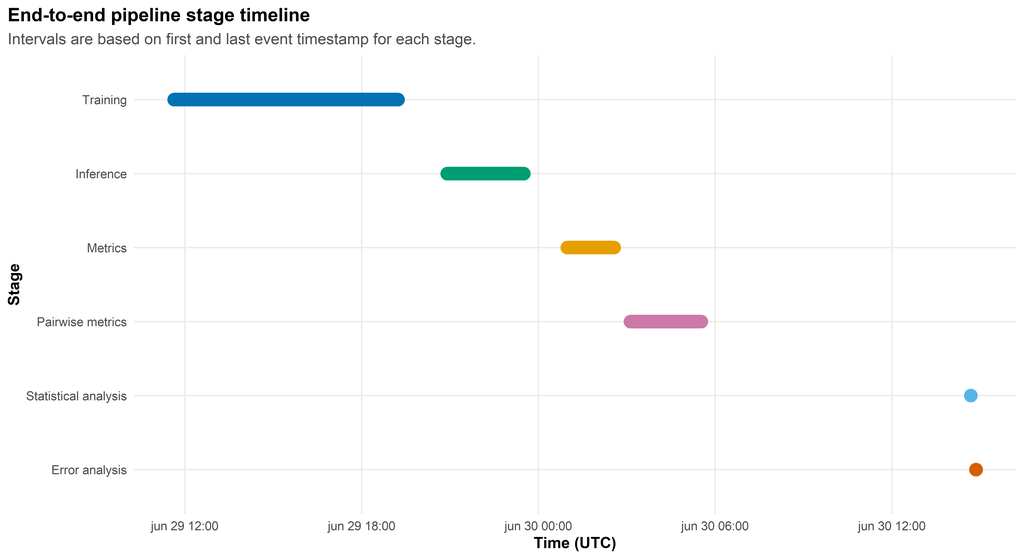

```r
p_stage_timeline <- stage_event_summary |>
  ggplot(aes(y = fct_rev(stage_label), color = stage)) +
  geom_segment(
    aes(x = first_event_utc, xend = last_event_utc, yend = fct_rev(stage_label)),
    linewidth = 5,
    lineend = "round",
    show.legend = FALSE
  ) +
  scale_color_manual(values = stage_palette, drop = FALSE) +
  labs(
    title = "End-to-end pipeline stage timeline",
    subtitle = "Intervals are based on first and last event timestamp for each stage.",
    x = "Time (UTC)",
    y = "Stage"
  ) +
  base_theme()

print(p_stage_timeline)
```

```r
save_pipeline_figure(
  p_stage_timeline,
  "01_pipeline_stage_timeline.png",
  width = 11,
  height = 6
)
```

## 15.2 Stage cost share

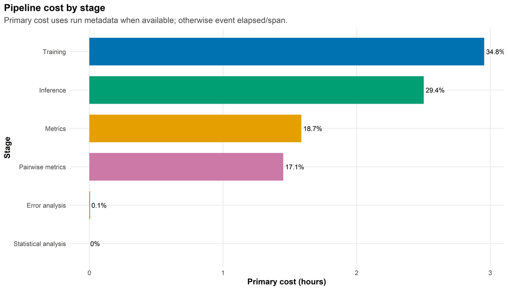

```r
p_stage_share <- unified_stage_cost |>
  ggplot(aes(x = fct_reorder(stage_label, primary_cost_seconds), y = primary_cost_hours, fill = stage)) +
  geom_col(width = 0.72, show.legend = FALSE) +
  geom_text(
    aes(label = paste0(round(share_of_primary_cost * 100, 1), "%")),
    hjust = -0.1,
    size = 3.5
  ) +
  coord_flip() +
  scale_fill_manual(values = stage_palette, drop = FALSE) +
  labs(
    title = "Pipeline cost by stage",
    subtitle = "Primary cost uses run metadata when available; otherwise event elapsed/span.",
    x = "Stage",
    y = "Primary cost (hours)"
  ) +
  base_theme()

print(p_stage_share)
```

```r
save_pipeline_figure(
  p_stage_share,
  "02_pipeline_cost_by_stage.png",
  width = 10.5,
  height = 6
)
```

## 15.3 Observed stage span vs primary cost

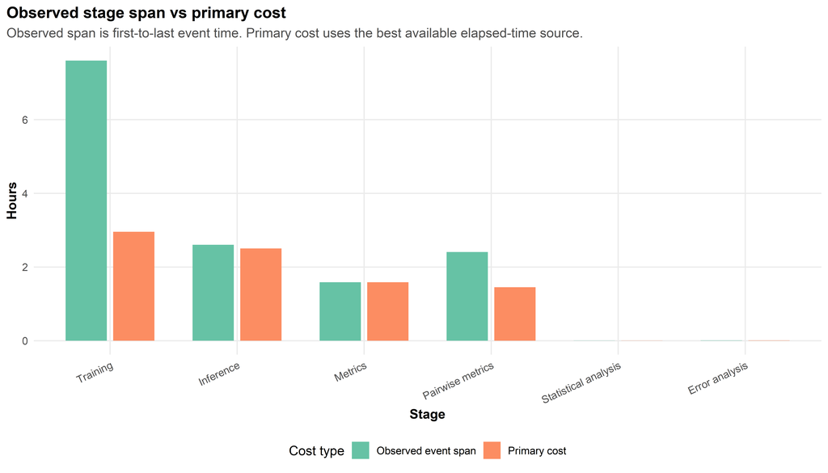

```r
p_observed_primary <- unified_stage_cost |>
  select(stage, stage_label, observed_stage_hours, primary_cost_hours) |>
  pivot_longer(
    cols = c(observed_stage_hours, primary_cost_hours),
    names_to = "cost_type",
    values_to = "hours"
  ) |>
  mutate(
    cost_type = recode(
      cost_type,
      observed_stage_hours = "Observed event span",
      primary_cost_hours = "Primary cost"
    )
  ) |>
  ggplot(aes(x = stage_label, y = hours, fill = cost_type)) +
  geom_col(position = position_dodge(width = 0.75), width = 0.65) +
  scale_fill_brewer(palette = "Set2") +
  labs(
    title = "Observed stage span vs primary cost",
    subtitle = "Observed span is first-to-last event time. Primary cost uses the best available elapsed-time source.",
    x = "Stage",
    y = "Hours",
    fill = "Cost type"
  ) +
  base_theme() +
  theme(axis.text.x = element_text(angle = 25, hjust = 1))

print(p_observed_primary)
```

```r
save_pipeline_figure(
  p_observed_primary,
  "03_observed_span_vs_primary_cost.png",
  width = 10.5,
  height = 6
)
```

## 15.4 Scenario total cost

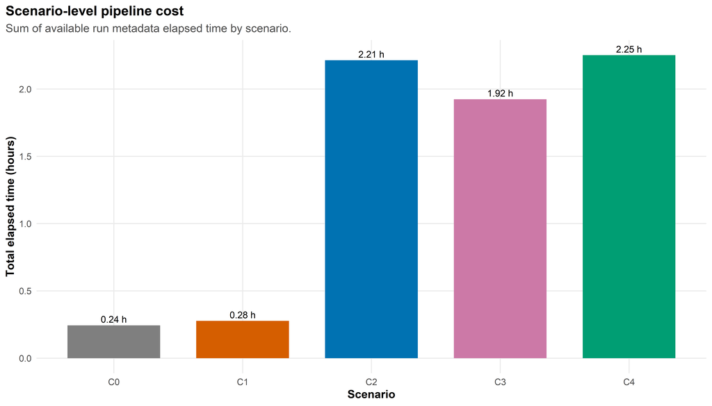

```r
p_scenario_total <- scenario_total_cost |>
  ggplot(aes(x = scenario_short, y = total_elapsed_hours, fill = scenario_short)) +
  geom_col(width = 0.72, show.legend = FALSE) +
  geom_text(
    aes(label = paste0(round(total_elapsed_hours, 2), " h")),
    vjust = -0.4,
    size = 3.5
  ) +
  scale_fill_manual(values = scenario_palette, drop = FALSE) +
  labs(
    title = "Scenario-level pipeline cost",
    subtitle = "Sum of available run metadata elapsed time by scenario.",
    x = "Scenario",
    y = "Total elapsed time (hours)"
  ) +
  base_theme()

print(p_scenario_total)
```

```r
save_pipeline_figure(
  p_scenario_total,
  "04_scenario_total_pipeline_cost.png",
  width = 10.5,
  height = 6
)
```

## 15.5 Scenario cost composition

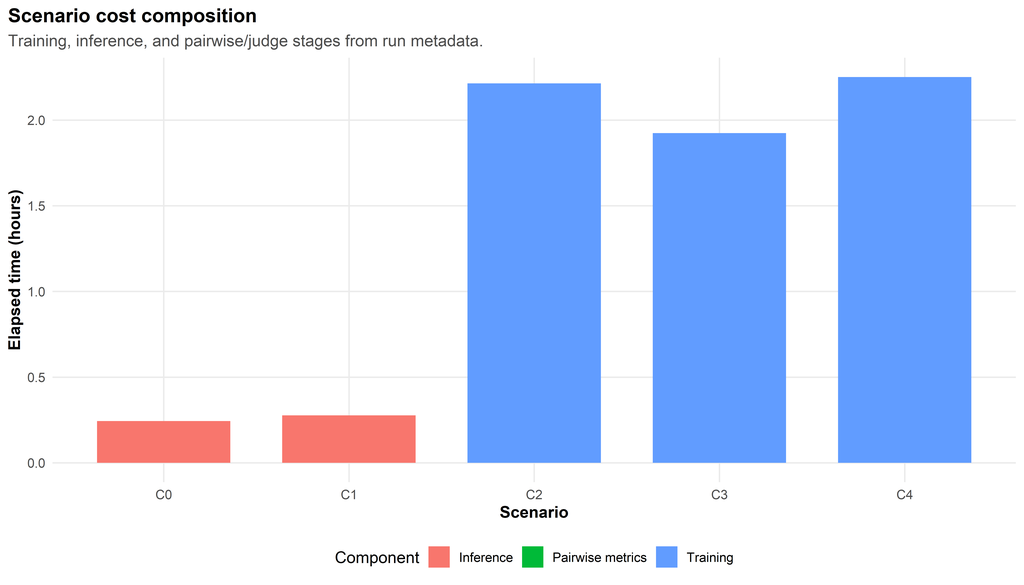

```r
scenario_composition <- scenario_total_cost |>
  select(scenario_id, scenario_short, training_hours, inference_hours, pairwise_hours) |>
  pivot_longer(
    cols = c(training_hours, inference_hours, pairwise_hours),
    names_to = "cost_component",
    values_to = "hours"
  ) |>
  mutate(
    cost_component = recode(
      cost_component,
      training_hours = "Training",
      inference_hours = "Inference",
      pairwise_hours = "Pairwise metrics"
    )
  )

p_scenario_composition <- scenario_composition |>
  ggplot(aes(x = scenario_short, y = hours, fill = cost_component)) +
  geom_col(width = 0.72) +
  labs(
    title = "Scenario cost composition",
    subtitle = "Training, inference, and pairwise/judge stages from run metadata.",
    x = "Scenario",
    y = "Elapsed time (hours)",
    fill = "Component"
  ) +
  base_theme()

print(p_scenario_composition)
```

```r
save_pipeline_figure(
  p_scenario_composition,
  "05_scenario_cost_composition.png",
  width = 10.5,
  height = 6
)
```

## 15.6 Run metadata duration distribution

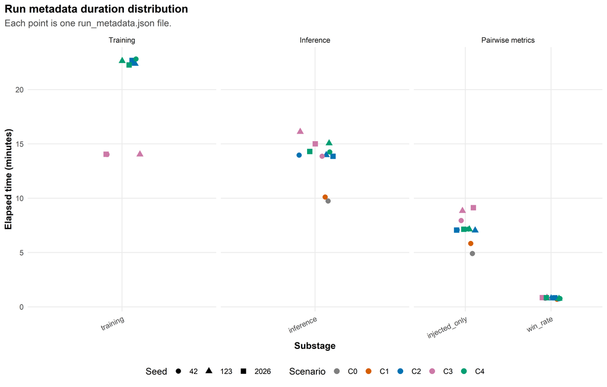

```r
p_run_distribution <- run_metadata |>
  filter(parse_ok, !is.na(stage), !is.na(elapsed_minutes)) |>
  ggplot(aes(x = substage, y = elapsed_minutes, color = scenario_short)) +
  geom_point(aes(shape = factor(seed)), size = 2.9, position = position_jitter(width = 0.12, height = 0)) +
  facet_wrap(~ stage_label, scales = "free_x") +
  scale_color_manual(values = scenario_palette, drop = FALSE) +
  labs(
    title = "Run metadata duration distribution",
    subtitle = "Each point is one run_metadata.json file.",
    x = "Substage",
    y = "Elapsed time (minutes)",
    color = "Scenario",
    shape = "Seed"
  ) +
  base_theme() +
  theme(axis.text.x = element_text(angle = 25, hjust = 1))

print(p_run_distribution)
```

```r
save_pipeline_figure(
  p_run_distribution,
  "06_run_metadata_duration_distribution.png",
  width = 11,
  height = 7
)
```

## 15.7 Event count by stage

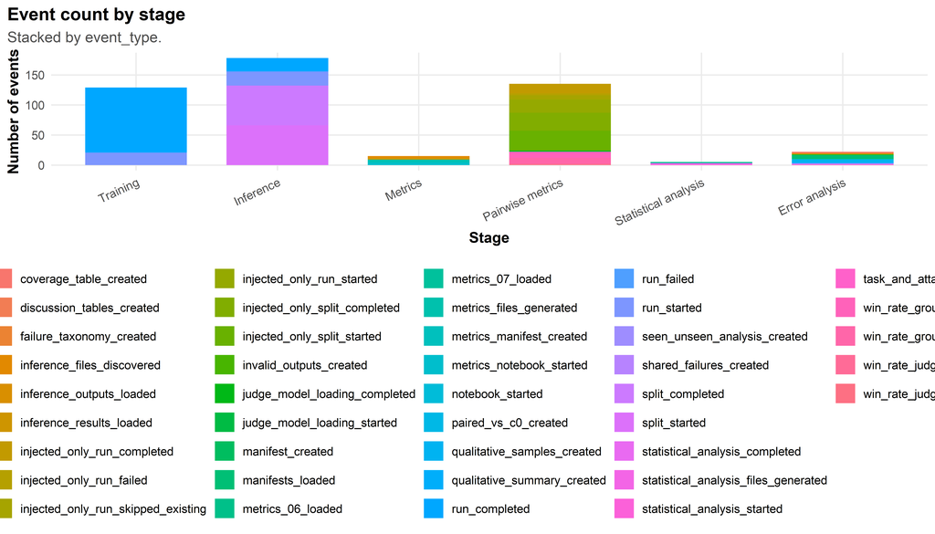

```r
p_event_counts <- all_events |>
  count(stage, stage_label, event_type, name = "n_events") |>
  ggplot(aes(x = stage_label, y = n_events, fill = event_type)) +
  geom_col(width = 0.72) +
  labs(
    title = "Event count by stage",
    subtitle = "Stacked by event_type.",
    x = "Stage",
    y = "Number of events",
    fill = "Event type"
  ) +
  base_theme() +
  theme(axis.text.x = element_text(angle = 25, hjust = 1))

print(p_event_counts)
```

```r
save_pipeline_figure(
  p_event_counts,
  "07_event_count_by_stage.png",
  width = 10.5,
  height = 6
)
```

## 15.8 Rows processed by stage

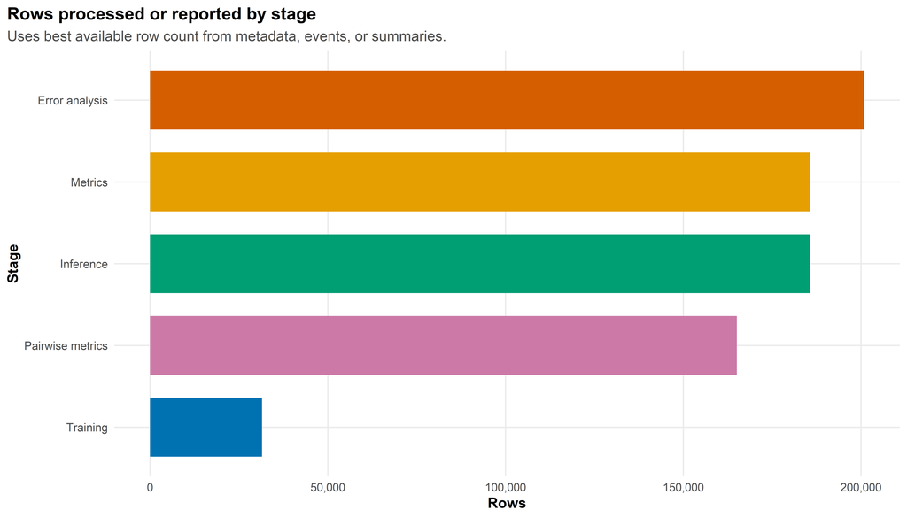

```r
rows_stage_plot <- unified_stage_cost |>
  mutate(
    best_rows = case_when(
      !is.na(run_metadata_split_rows) & run_metadata_split_rows > 0 ~ run_metadata_split_rows,
      !is.na(run_metadata_rows) & run_metadata_rows > 0 ~ run_metadata_rows,
      !is.na(event_rows_sum) & event_rows_sum > 0 ~ event_rows_sum,
      !is.na(num_inference_rows) & num_inference_rows > 0 ~ num_inference_rows,
      !is.na(total_inference_rows) & total_inference_rows > 0 ~ total_inference_rows,
      TRUE ~ NA_real_
    )
  )

p_rows_stage <- rows_stage_plot |>
  filter(!is.na(best_rows)) |>
  ggplot(aes(x = fct_reorder(stage_label, best_rows), y = best_rows, fill = stage)) +
  geom_col(width = 0.72, show.legend = FALSE) +
  coord_flip() +
  scale_fill_manual(values = stage_palette, drop = FALSE) +
  scale_y_continuous(labels = scales::comma_format()) +
  labs(
    title = "Rows processed or reported by stage",
    subtitle = "Uses best available row count from metadata, events, or summaries.",
    x = "Stage",
    y = "Rows"
  ) +
  base_theme()

print(p_rows_stage)
```

```r
save_pipeline_figure(
  p_rows_stage,
  "08_rows_processed_by_stage.png",
  width = 10.5,
  height = 6
)
```

## 15.9 Error files by stage

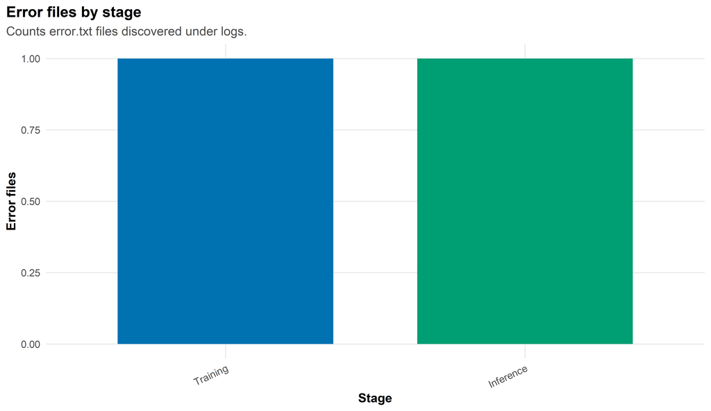

```r
if (nrow(pipeline_error_summary) > 0) {
  p_errors <- pipeline_error_summary |>
    group_by(stage, stage_label) |>
    summarise(n_error_files = sum(n_error_files), .groups = "drop") |>
    ggplot(aes(x = stage_label, y = n_error_files, fill = stage)) +
    geom_col(width = 0.72, show.legend = FALSE) +
    scale_fill_manual(values = stage_palette, drop = FALSE) +
    labs(
      title = "Error files by stage",
      subtitle = "Counts error.txt files discovered under logs.",
      x = "Stage",
      y = "Error files"
    ) +
    base_theme() +
    theme(axis.text.x = element_text(angle = 25, hjust = 1))

  print(p_errors)

  save_pipeline_figure(
    p_errors,
    "09_error_files_by_stage.png",
    width = 9.5,
    height = 5.5
  )
}
```

# 16 Paper-ready table

```r
paper_pipeline_table <- unified_stage_cost |>
  select(
    stage_label,
    notebook,
    n_events,
    run_metadata_files,
    observed_stage_seconds,
    primary_cost_seconds,
    primary_cost_source,
    share_of_primary_cost,
    event_rows_sum,
    run_metadata_rows,
    run_metadata_split_rows,
    run_metadata_train_rows
  ) |>
  mutate(
    observed_stage_hours = fmt_number(observed_stage_seconds / 3600),
    primary_cost_hours = fmt_number(primary_cost_seconds / 3600),
    share_of_primary_cost = fmt_pct(share_of_primary_cost),
    event_rows_sum = fmt_number(event_rows_sum, accuracy = 1),
    run_metadata_rows = fmt_number(run_metadata_rows, accuracy = 1),
    run_metadata_split_rows = fmt_number(run_metadata_split_rows, accuracy = 1),
    run_metadata_train_rows = fmt_number(run_metadata_train_rows, accuracy = 1)
  ) |>
  select(
    stage_label,
    notebook,
    n_events,
    run_metadata_files,
    observed_stage_hours,
    primary_cost_hours,
    primary_cost_source,
    share_of_primary_cost,
    event_rows_sum,
    run_metadata_rows,
    run_metadata_split_rows,
    run_metadata_train_rows
  )

write_pipeline_csv(paper_pipeline_table, "16_paper_ready_pipeline_runtime_table.csv")

paper_pipeline_table |>
  knitr::kable(
    caption = "Table 14 - Paper-ready pipeline runtime table."
  )
```

Table 14 - Paper-ready pipeline runtime table.

| stage_label | notebook | n_events | run_metadata_files | observed_stage_hours | primary_cost_hours | primary_cost_source | share_of_primary_cost | event_rows_sum | run_metadata_rows | run_metadata_split_rows | run_metadata_train_rows |
| --- | --- | --- | --- | --- | --- | --- | --- | --- | --- | --- | --- |
| Training | 04_run_training | 129 | 9 | 7.60 | 2.96 | run_metadata_elapsed_sum | 34.8% | 0 | 31,500 | 0 | 31,500 |
| Inference | 05_run_inference | 178 | 11 | 2.60 | 2.50 | run_metadata_elapsed_sum | 29.4% | 372,768 | 0 | 185,724 | 0 |
| Metrics | 06_compute_metrics | 15 | - | 1.59 | 1.59 | event_timestamp_span | 18.7% | 0 | - | - | - |
| Pairwise metrics | 07_pairwise_and_injected_metrics | 135 | 21 | 2.41 | 1.45 | run_metadata_elapsed_sum | 17.1% | 481,380 | 3,000 | 165,088 | 0 |
| Statistical analysis | 08_statistical_analysis | 5 | - | 0.00 | 0.00 | event_timestamp_span | 0.0% | 0 | - | - | - |
| Error analysis | - | 22 | - | 0.00 | 0.00 | event_timestamp_span | 0.1% | 200,864 | - | - | - |

# 17 Interpretation notes

```r
cat("
## How to interpret this report

This report uses two notions of time.

Observed stage span is the time between the first and last event timestamp in each stage log. It is useful for timeline analysis.

Primary cost is the best available elapsed-time estimate for each stage. When run_metadata.json files exist, the primary cost is the sum of run metadata elapsed_seconds. Otherwise, the report falls back to elapsed_seconds found in event rows, and then to the event timestamp span.

Because some stages include multiple scenario/seed runs, primary cost can differ from wall-clock duration. It estimates accumulated compute or task time, while observed stage span estimates calendar time.

Training and inference are model-execution stages. Metrics, statistical analysis, and error analysis are mostly post-processing stages. Pairwise metrics can include both additional inference-style injected-only runs and judge-based win-rate runs.

C0 and C1 have no adapter-training cost, but they can have inference, injected-only, and pairwise metric costs.
")
```

## 17.1 How to interpret this report

This report uses two notions of time.

Observed stage span is the time between the first and last event timestamp in each stage log. It is useful for timeline analysis.

Primary cost is the best available elapsed-time estimate for each stage. When run_metadata.json files exist, the primary cost is the sum of run metadata elapsed_seconds. Otherwise, the report falls back to elapsed_seconds found in event rows, and then to the event timestamp span.

Because some stages include multiple scenario/seed runs, primary cost can differ from wall-clock duration. It estimates accumulated compute or task time, while observed stage span estimates calendar time.

Training and inference are model-execution stages. Metrics, statistical analysis, and error analysis are mostly post-processing stages. Pairwise metrics can include both additional inference-style injected-only runs and judge-based win-rate runs.

C0 and C1 have no adapter-training cost, but they can have inference, injected-only, and pairwise metric costs.

# 18 Generated files

Tables are saved in:

```
tables/pipeline_runtime_analysis/
```

Figures are saved in:

```
figures/pipeline_runtime_analysis/
```

Main files:

```
01_stage_paths.csv
02_all_pipeline_events.csv
03_stage_event_timeline_summary.csv
04_stage_summary_json_records.csv
05_all_run_metadata.csv
06_stage_cost_from_run_metadata.csv
07_unified_stage_cost_summary.csv
08_pipeline_total_summary.csv
09_scenario_stage_cost.csv
10_scenario_total_pipeline_cost.csv
11_pipeline_error_files.csv
12_pipeline_error_summary.csv
13_run_status_summary.csv
14_stage_bottleneck_table.csv
15_scenario_bottleneck_table.csv
16_paper_ready_pipeline_runtime_table.csv

01_pipeline_stage_timeline.png
02_pipeline_cost_by_stage.png
03_observed_span_vs_primary_cost.png
04_scenario_total_pipeline_cost.png
05_scenario_cost_composition.png
06_run_metadata_duration_distribution.png
07_event_count_by_stage.png
08_rows_processed_by_stage.png
09_error_files_by_stage.png
```